# Active Learning Workshop

Bob Horton

November 21, 2017

# Classifying wood knots

```r
### Libraries ###
library(dplyr)
library(tidyr)
library(ggplot2)

library(pROC)

### Meta-hyperparameters ###
set.seed(1)  ###

L1_PENALTY <- 1e-2
L2_PENALTY <- 1e-2

INITIAL_EXAMPLES_PER_CLASS <- 6  # cases from the labelled dataset used to train the initial model

BALANCE_CLASSES <- TRUE  # should we try to pick some cases from each of the three classes?

ADDITIONAL_CASES_TO_LABEL <- 2  # cases per class if BALANCE_CLASSES is TRUE

NUM_ITERATIONS <- 10

MONTE_CARLO_SAMPLES <- 100

# This order determines the order of factor levels
KNOT_CLASSES <- setNames(nm=c("sound_knot", "dry_knot", "encased_knot"))

LABELLED_FEATURIZED_DATA <- "labelled_knots_featurized_resnet18.Rds"
UNLABELLED_FEATURIZED_DATA <- "unlabelled_knots_featurized_large_resnet18.Rds"

unlabelled_knot_data_df <- readRDS(UNLABELLED_FEATURIZED_DATA)
labelled_knot_data_df <- readRDS(LABELLED_FEATURIZED_DATA)

PSEUDOLABELS_FILE <- "unlabelled_knot_info_area_small.csv" # "unlabelled_knot_info.csv" # We'll pretend these come from our labellers

inputs <- grep("^Feature", names(labelled_knot_data_df), value=TRUE)
outcome <- "knot_class"
FORM <- formula(paste(outcome, paste(inputs, collapse="+"), sep="~"))
```

### Split labelled data into training and test sets

```r
class_samples <- lapply(KNOT_CLASSES, function(kc) sample(which(labelled_knot_data_df$knot_class == kc), INITIAL_EXAMPLES_PER_CLASS))

in_training_set <- (1:nrow(labelled_knot_data_df) %in% unlist(class_samples))

initial_training_set <- labelled_knot_data_df[in_training_set,]
TEST_SET <- labelled_knot_data_df[!in_training_set,]

table(initial_training_set$knot_class)
```

```
##
##   sound_knot     dry_knot encased_knot
##            6            6            6
```

```r
table(initial_training_set$knot_class)/nrow(initial_training_set)
```

```
##
##   sound_knot     dry_knot encased_knot
##    0.3333333    0.3333333    0.3333333
```

```r
saveRDS(TEST_SET, "test_set.Rds")
saveRDS(initial_training_set, "initial_training_set.Rds")
```

## Initial model for knot classes

First we build a model on the available training data, and test on the test data. This model will focus on classifying a knot image into three categories: “sound_knot”, “dry_knot”, and “encased_knot”. In the blog post there was also a category for “decayed_knot”, but we will consider decay a separate attribute, and not use it in this model. We will use only a small number of the available labelled cases for training, and the rest for testing. This makes a larger test set and a smaller training set than in the blog post.

### Fit model to initial training set

```r
source("woodknots_active_learning_lib.R")

pseudolabel_function <- get_pseudolabelling_function(PSEUDOLABELS_FILE, KNOT_CLASSES)

initial_model_results <- fit_and_evaluate_model(initial_training_set)

# still_unlabelled <- setdiff(unlabelled_knot_data_df$path, been_there)
# unlabelled_df <- unlabelled_knot_data_df[unlabelled_knot_data_df$path %in% still_unlabelled,]

select_cases <- function(model, available_cases, N=ADDITIONAL_CASES_TO_LABEL, balance_classes=BALANCE_CLASSES){
    predictions_df <- rxPredict(model, available_cases, extraVarsToWrite=c("path"))
    names(predictions_df) <- c("path", "pred_class", "sound_knot", "dry_knot", "encased_knot")

    selected <- predictions_df %>%
      mutate(max_prob=apply(cbind(sound_knot, dry_knot, encased_knot), 1, max)) %>%
      arrange(max_prob)  # -entropy

    if (balance_classes){
      return(bind_rows(
        selected[selected$pred_class=="sound_knot",][1:N,],
        selected[selected$pred_class=="dry_knot",][1:N,],
        selected[selected$pred_class=="encased_knot",][1:N,]
      ))
    } else{
      return(head(selected, n=N))
    }
}

initial_model_results$selected <- select_cases(initial_model_results$model, unlabelled_knot_data_df)
```

```
## Elapsed time: 00:00:00.1540154
```

## Results for initial model

### ROC curves

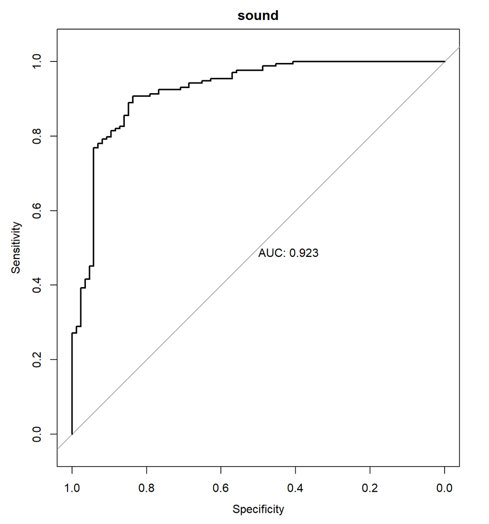

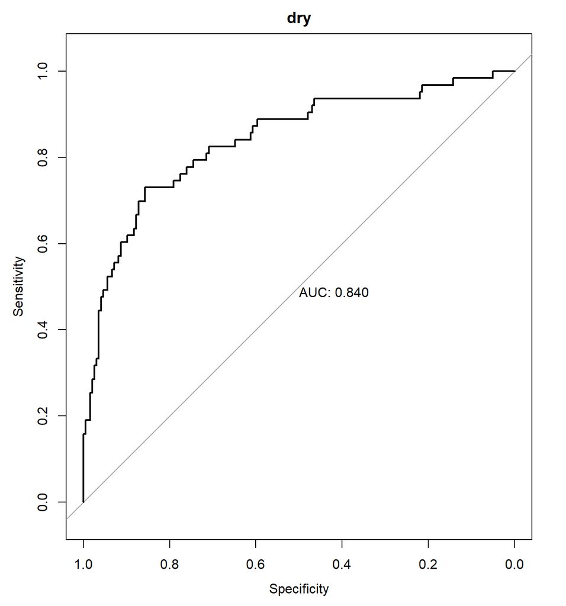

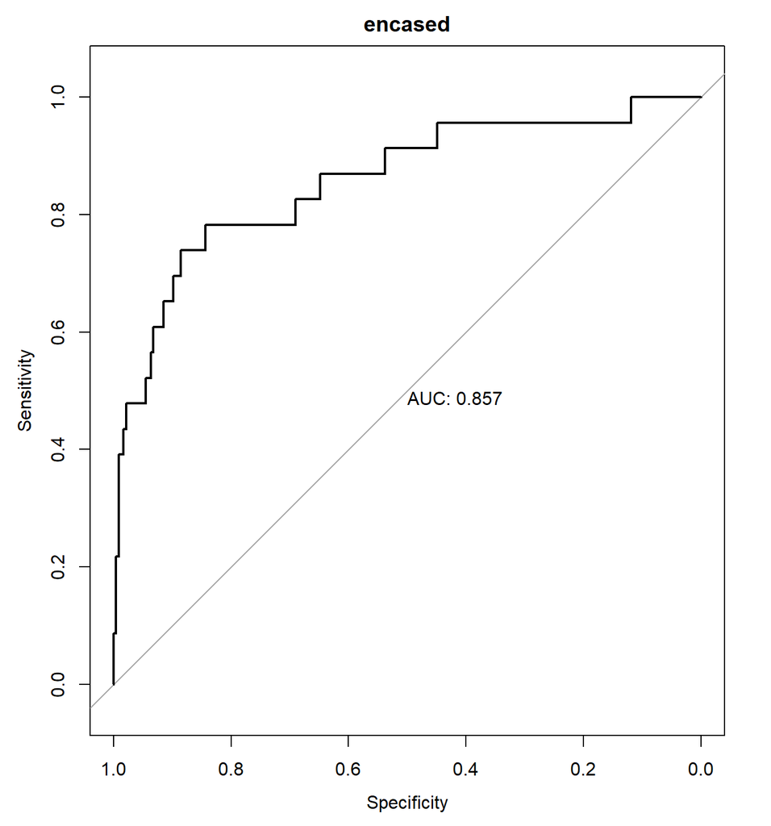

```r
# op <- par(mfrow=c(3,1), no.readonly = TRUE)
mapply(plot, x=initial_model_results$roc_list, main=names(initial_model_results$roc_list), print.auc=TRUE) %>% invisible
```

```r
# par(op)
```

#### Confusion matrix

```r
initial_model_results$confusion
```

```
##               pred_class
## knot_class     sound_knot dry_knot encased_knot
##   sound_knot          139       25            9
##   dry_knot              3       46           14
##   encased_knot          5        3           15
```

### Performance summary

```r
initial_model_results$performance
```

```
##    accuracy   auc_sound     auc_dry auc_encased  negentropy
##   0.7722008   0.9229735   0.8399741   0.8572218  -0.7620452
```

### Histograms of class scores

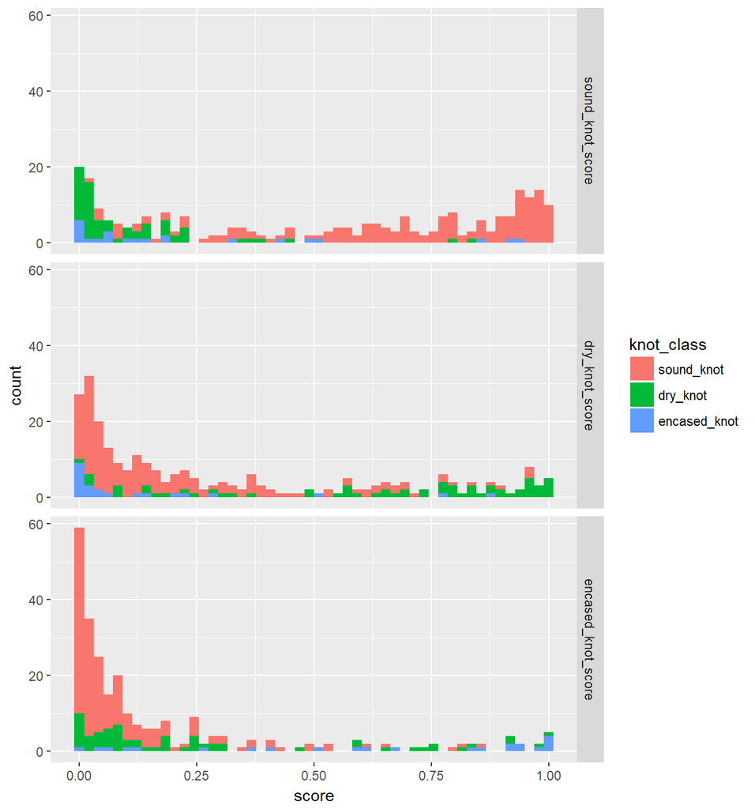

```r
plot_class_histograms(initial_model_results$test_predictions)
```

### Plot of test cases on entropy surface

Here we’ll stick to a 2D representation, where the yellow background indicates regions of lower entropy.

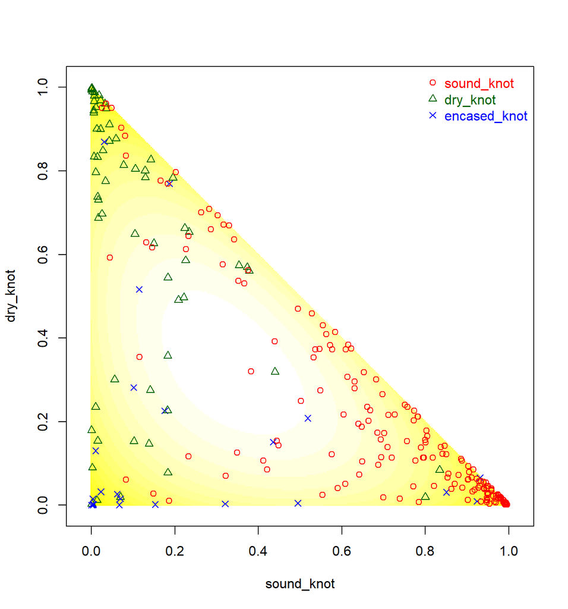

```r
plot_class_separation(initial_model_results$test_predictions)
```

## Iterate modelling, case selection, and (pseudo) labelling

These are the cases selected by the initial model for labelling:

```r
initial_model_results$selected
```

```
##               path   pred_class sound_knot  dry_knot encased_knot
## 1 st1568_knot2.png   sound_knot  0.3905281 0.3124349    0.2970370
## 2 st1454_knot1.png   sound_knot  0.4017069 0.3780740    0.2202190
## 3 st1116_knot0.png     dry_knot  0.3921232 0.3983140    0.2095627
## 4 st1176_knot1.png     dry_knot  0.3979095 0.4025992    0.1994913
## 5 st1487_knot1.png encased_knot  0.3379171 0.2467965    0.4152864
## 6 st1125_knot0.png encased_knot  0.1813806 0.3910638    0.4275556
##    max_prob
## 1 0.3905281
## 2 0.4017069
## 3 0.3983140
## 4 0.4025992
## 5 0.4152864
## 6 0.4275556
```

```r
(initial_model_results$selected_labelled <- initial_model_results$selected %>% pseudolabel_function)
```

```
##               path   pred_class sound_knot  dry_knot encased_knot
## 1 st1568_knot2.png   sound_knot  0.3905281 0.3124349    0.2970370
## 2 st1454_knot1.png   sound_knot  0.4017069 0.3780740    0.2202190
## 3 st1116_knot0.png     dry_knot  0.3921232 0.3983140    0.2095627
## 4 st1176_knot1.png     dry_knot  0.3979095 0.4025992    0.1994913
## 5 st1487_knot1.png encased_knot  0.3379171 0.2467965    0.4152864
## 6 st1125_knot0.png encased_knot  0.1813806 0.3910638    0.4275556
##    max_prob knot_class
## 1 0.3905281 sound_knot
## 2 0.4017069 sound_knot
## 3 0.3983140   dry_knot
## 4 0.4025992 sound_knot
## 5 0.4152864   dry_knot
## 6 0.4275556   dry_knot
```

```r
new_sample <- initial_model_results$selected_labelled %>% get_new_pseudolabelled_sample

current_training_set <- rbind(initial_training_set, new_sample[names(initial_training_set)])

ALREADY_EVALUATED <- initial_model_results$selected$path

iteration_results <- lapply(1:NUM_ITERATIONS, function(i){
  results <- fit_and_evaluate_model(current_training_set)

  candidate_cases <- unlabelled_knot_data_df[(unlabelled_knot_data_df$path %in% setdiff(unlabelled_knot_data_df$path, ALREADY_EVALUATED)),]
  results$selected <- select_cases(results$model, candidate_cases)

  ALREADY_EVALUATED <<- c(ALREADY_EVALUATED, results$selected$path)
  results$selected_labelled <- results$selected %>% pseudolabel_function
  next_sample <- results$selected %>% pseudolabel_function %>% get_new_pseudolabelled_sample

  current_training_set <<- rbind(current_training_set, next_sample[names(current_training_set)])

  results
})
```

```
## Elapsed time: 00:00:00.1713261
## Elapsed time: 00:00:00.1758444
## Elapsed time: 00:00:00.1718233
## Elapsed time: 00:00:00.1777573
## Elapsed time: 00:00:00.1709022
## Elapsed time: 00:00:00.1697694
## Elapsed time: 00:00:00.1751214
## Elapsed time: 00:00:00.1861378
## Elapsed time: 00:00:00.1764492
## Elapsed time: 00:00:00.1769460
```

These are the cases selected at each iteration, together with the scores produced by the model for that iteration. The `knot_class` column was added by the pseudolabelling function.

```r
lapply(iteration_results, function(ires) ires$selected_labelled)
```

```
## [[1]]
##               path   pred_class sound_knot  dry_knot encased_knot
## 1 st1146_knot0.png   sound_knot  0.3885931 0.3084019    0.3030050
## 2 st1521_knot1.png   sound_knot  0.4077989 0.3714764    0.2207247
## 3 st1209_knot0.png     dry_knot  0.1899919 0.4212564    0.3887517
## 4 st1495_knot1.png     dry_knot  0.2506396 0.4306541    0.3187062
## 5 st1822_knot1.png encased_knot  0.2448014 0.3574488    0.3977498
## 6 st1085_knot0.png encased_knot  0.1924053 0.3888145    0.4187803
##    max_prob   knot_class
## 1 0.3885931   sound_knot
## 2 0.4077989 encased_knot
## 3 0.4212564   sound_knot
## 4 0.4306541     dry_knot
## 5 0.3977498   sound_knot
## 6 0.4187803     dry_knot
```

[output cut: 144 more lines]

This shows the change in the metrics, with each row showing an iteration. The ‘negentropy’ metric is the negative entropy across all three class probabilities.

```r
do.call("rbind", lapply(iteration_results, function(ires) ires$performance))
```

```
##        accuracy auc_sound   auc_dry auc_encased negentropy
##  [1,] 0.8030888 0.9276112 0.9067055   0.8778556 -0.6569905
##  [2,] 0.8223938 0.9384998 0.9296242   0.8621960 -0.4646405
##  [3,] 0.8378378 0.9647130 0.9632329   0.8434046 -0.4249073
##  [4,] 0.8648649 0.9809786 0.9646097   0.8621960 -0.3642842
##  [5,] 0.8687259 0.9742573 0.9586168   0.8784083 -0.3834385
##  [6,] 0.8610039 0.9709638 0.9598316   0.8601695 -0.3160554
##  [7,] 0.8648649 0.9723081 0.9561063   0.8638541 -0.2918295
##  [8,] 0.8687259 0.9683425 0.9468740   0.8546426 -0.2672865
##  [9,] 0.8803089 0.9717704 0.9586978   0.8817244 -0.2642162
## [10,] 0.8957529 0.9728458 0.9602365   0.8878040 -0.2244327
```

### Visualizing improvement for actively learned model

Here we plot a series of ROC curves showing how performance changes with iterations of active learning.

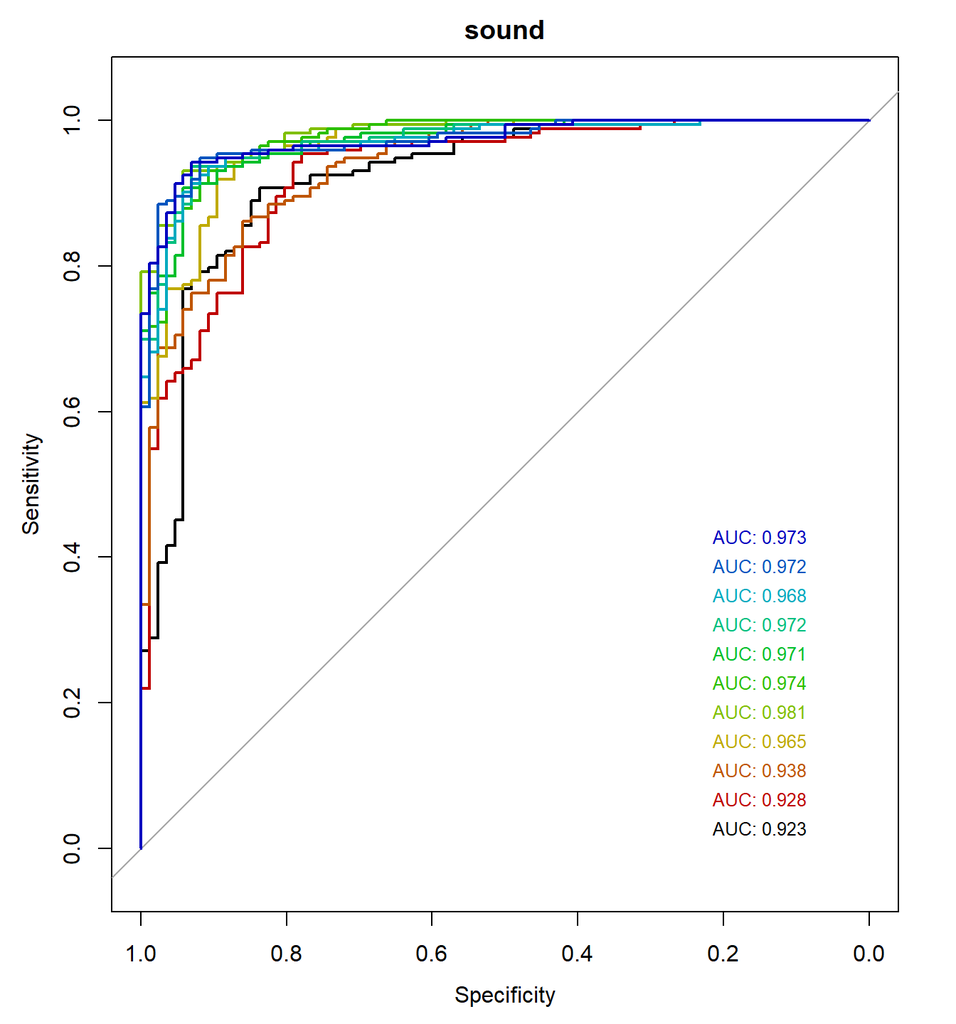

```r
plot_roc_history("sound", initial_model_results, iteration_results)
```

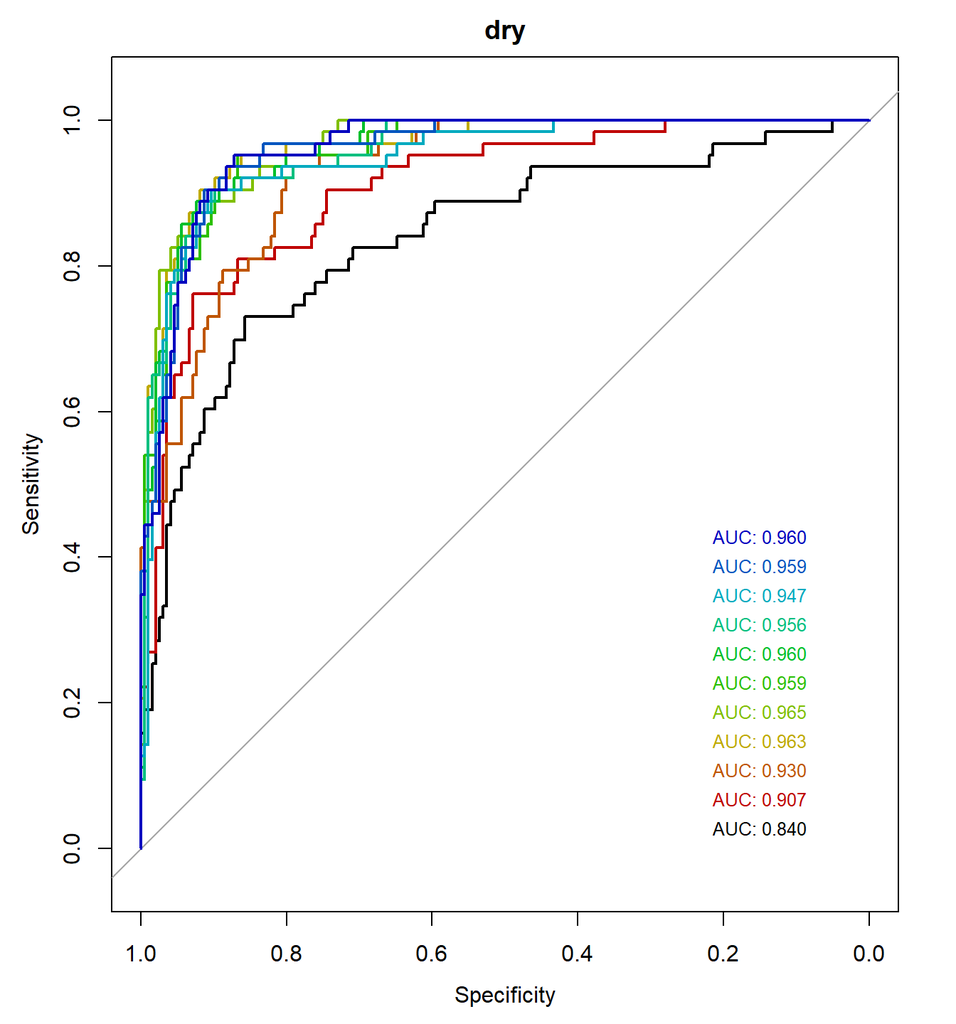

```r
plot_roc_history("dry", initial_model_results, iteration_results)
```

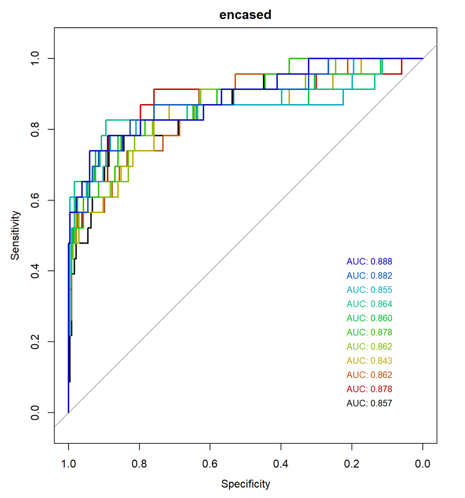

```r
plot_roc_history("encased", initial_model_results, iteration_results)
```

### Final model results

```r
final_model_results <- iteration_results[[NUM_ITERATIONS]]
```

### Confusion Matrix

```r
final_model_results$confusion
```

```
##               pred_class
## knot_class     sound_knot dry_knot encased_knot
##   sound_knot          163       10            0
##   dry_knot              5       57            1
##   encased_knot          1       10           12
```

### Performance summary

Summary of performance using cases selected with active learning:

```r
(selected_sample_results <- final_model_results$performance)
```

```
##    accuracy   auc_sound     auc_dry auc_encased  negentropy
##   0.8957529   0.9728458   0.9602365   0.8878040  -0.2244327
```

### Histograms of class scores for final model

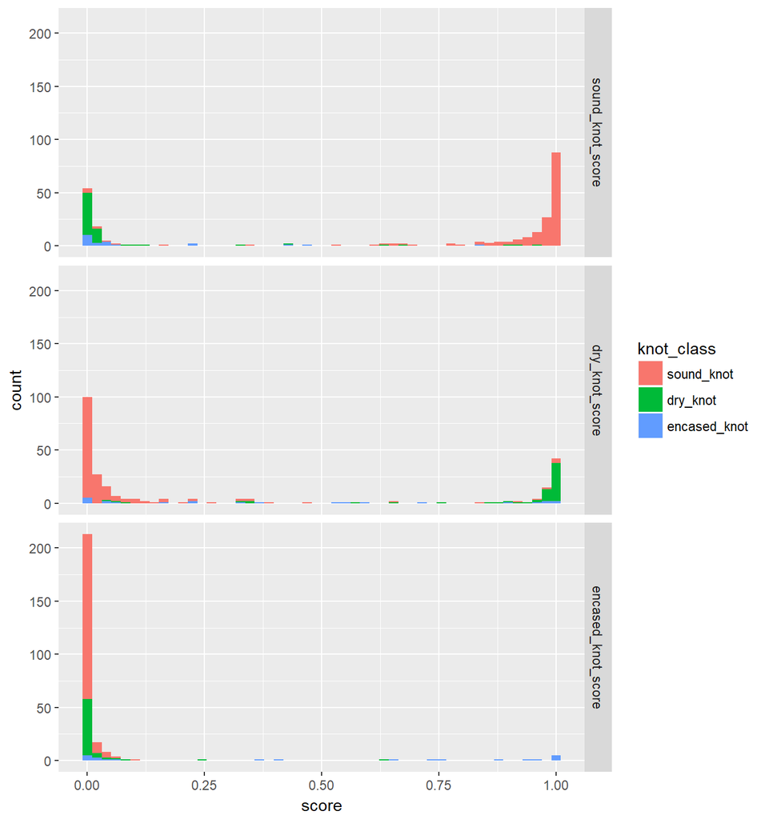

```r
plot_class_histograms(final_model_results$test_predictions)
```

### Entropy surface plot

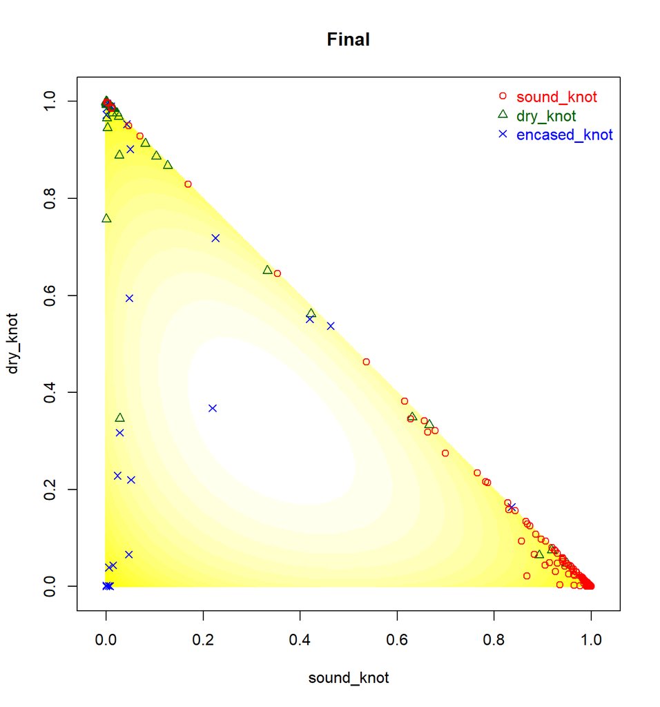

```r
plot_class_separation(final_model_results$test_predictions, main="Final")
```

## Monte Carlo Estimation of P-values

What is the probability that a set of randomly chosen cases would improve the performance of the model as much as the selected cases did? We’ll add the same number of examples to the training set, except that now they will be randomly chosen. We’ll repeat this sampling, training, and evaluation process 100 times, and see how many of those times we beat the performance of the selected cases.

```r
(N <- iteration_results[[NUM_ITERATIONS]]$tss - nrow(initial_training_set))
```

```
## [1] 54
```

```r
available_cases <- pseudolabel_function(unlabelled_knot_data_df)

random_sample_results <- sapply(1:MONTE_CARLO_SAMPLES, function(i){
  new_sample <- available_cases[sample(1:nrow(available_cases), N, replace=FALSE),]

  training_set_new <- rbind(initial_training_set, new_sample[names(initial_training_set)])

  fit_and_evaluate_model(training_set_new)$performance
})
```

```r
saveRDS(random_sample_results, sprintf("random_sample_results_iteration%02d.Rds", NUM_ITERATIONS))
```

### P-values

```r
mapply (
  function(metric) sum(random_sample_results[metric,] >= selected_sample_results[[metric]]),
  row.names(random_sample_results)
) / MONTE_CARLO_SAMPLES
```

```
##    accuracy   auc_sound     auc_dry auc_encased  negentropy
##        0.00        0.20        0.05        0.39        0.00
```

## Model trained with all available “unlabelled” cases

For comparison, we’ll build a model as though we had gone through and labelled all 373 of the useable new examples.

```r
training_set_full <- rbind(initial_training_set, available_cases[names(initial_training_set)])

full_model_results <- fit_and_evaluate_model(training_set_full)

full_model_results$confusion
```

```
##               pred_class
## knot_class     sound_knot dry_knot encased_knot
##   sound_knot          158       13            2
##   dry_knot              3       55            5
##   encased_knot          1        8           14
```

```r
full_model_results$performance
```

```
##    accuracy   auc_sound     auc_dry auc_encased  negentropy
##   0.8764479   0.9772147   0.9469550   0.9261238  -0.1737701
```

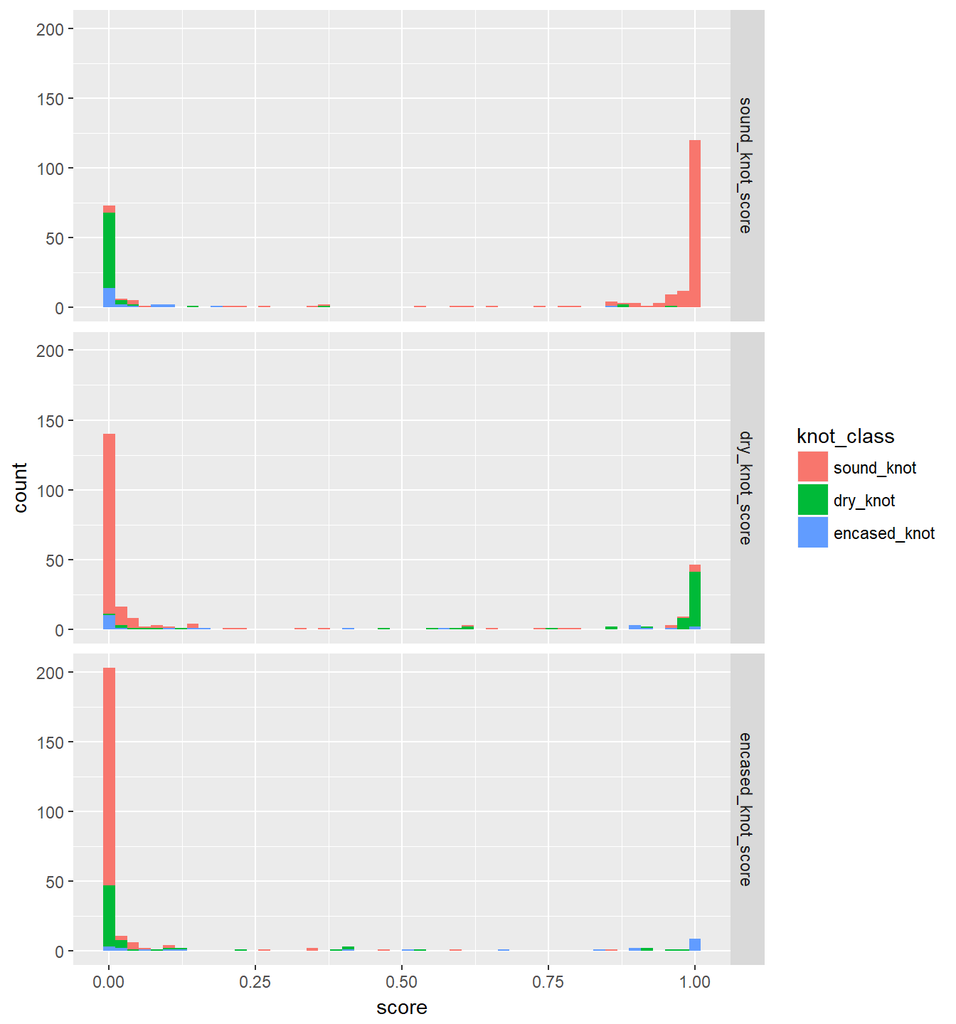

```r
plot_class_histograms(full_model_results$test_predictions)
```

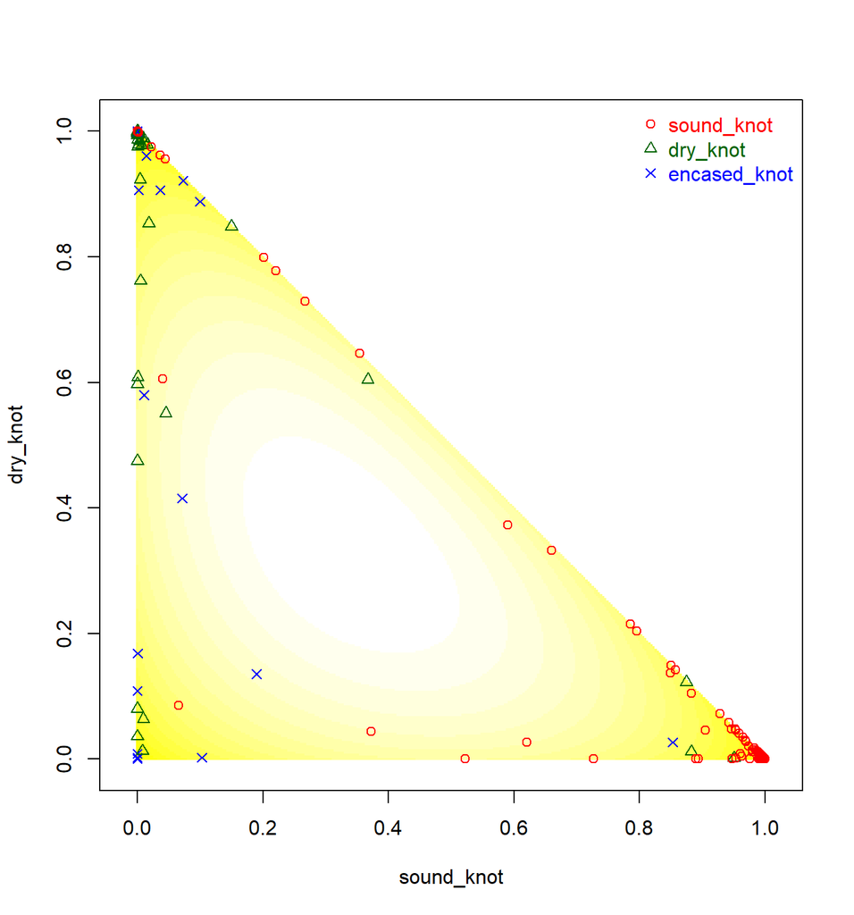

```r
plot_class_separation(full_model_results$test_predictions)
```

```r
# saveRDS(training_set_full, "training_set_full.Rds")
# saveRDS(test_set, "test_set.Rds")
```